# Respiratory quality of life (SGRQ total) in adults with and without HIV

Dataset 11: HIV infection and exercise capacity

RSR feasibility analysis

2026-08-03

# Introduction

The Pittsburgh/UCSF lung-function study enrolled adults living with HIV and HIV-uninfected comparators from two US clinical centres and assessed all of them identically with a six-minute walk test, spirometry, diffusing capacity and the St George’s Respiratory Questionnaire (Fitzpatrick and colleagues, *PLOS ONE* 2019). This teaching extract holds 427 participants, 297 of them living with HIV. The SGRQ is the standard patient-reported measure of respiratory health status: it runs from 0 to 100 with higher scores meaning worse quality of life, a four-point change is the accepted minimal important difference, and it is the outcome that determines whether measured lung impairment actually matters to the person who has it.

**Aim.** Among these adults, we examined which of HIV status, age, sex, current smoking, cumulative pack-years, blood pressure, haemoglobin and the three lung function measurements (FEV1, FVC and DLCO, each as a percentage of predicted) are independently associated with the SGRQ total score, mutually adjusting for the others.

This is a *Purpose 3* analysis: several predictors are of interest and the question is which remain associated with the outcome after mutual adjustment.

# Methods

**Data source.** A cross-sectional analysis of participants enrolled at two US clinical centres (Pittsburgh and San Francisco) into a cohort study of lung function in HIV. The extract contains 427 adults aged 21 to 79 and 21 variables; 297 (69.6%) are living with HIV. All measurements were made at a single study visit.

**Variables.** The outcome is `sgrq_total`, the St George’s Respiratory Questionnaire total score on a 0-100 scale where **higher is worse** (observed range 0.0 to 85.4), treated as continuous. Predictors are HIV status (reference HIV-negative, the clinically unexposed group), age (years), sex (reference male, the larger group), current smoking (reference not a current smoker), cumulative smoking exposure (pack-years), systolic and diastolic blood pressure (mmHg), haemoglobin (g/dL), and FEV1, FVC and DLCO each expressed as a percentage of the predicted value for a person of the same age, sex and height.

**The three SGRQ subscales are excluded, and this is not negotiable.** The questionnaire’s total score is a fixed weighted combination of its symptoms, activity and impacts components: regressing `sgrq_total` on the three subscales in this file returns R-squared 0.9996, i.e. they reproduce the outcome to within rounding error. Putting any of them on the right-hand side is regressing a score on its own components, which is circular and tells us nothing.

**Smoking is entered once, as dose plus a current-smoking indicator.** The shipped `smoking_status` variable has three levels (never 132, former 106, current 189) and `pack_years` is **exactly zero for all 132 never-smokers and strictly positive for every ever-smoker**, so the two encode the same never/ever distinction twice. Entering the untouched factor alongside pack-years would force the former- and current-smoker contrasts to be estimated at zero pack-years, a value no ever-smoker in this sample has. We therefore keep `pack_years` as the cumulative-dose term and add one binary indicator for *current* smoking, which is the piece of information pack-years cannot carry.

**Variables deliberately excluded.** `cd4_count`, `on_antiretroviral` and `viral_load_detectable` are **missing by design** for participants without HIV; any of them in the model deletes most or all of the HIV-negative comparison group. `mmrc_dyspnoea` is excluded on two grounds: it is missing for 111 participants, **all of them HIV-positive**, and it is a breathlessness rating that overlaps conceptually with the SGRQ symptoms domain. `six_min_walk_m` is excluded because it is analysed as a separate outcome and is best regarded as a parallel consequence of lung disease rather than a determinant of quality of life.

**Statistical analysis.** `lm()`, justified because the outcome is a continuous score with many distinct values. We fitted a univariable model for each predictor first, then a single multivariable model containing all of them. Predictors were chosen in advance on subject-matter grounds, not by significance. Significance threshold 0.05; estimates are reported with 95% confidence intervals. Assumptions were checked with `performance::check_model()`, and because non-constant variance was flagged we additionally report HC3 heteroscedasticity-consistent standard errors. Analysis used R version 4.6.0 (2026-04-24) with tidyverse, gtsummary and performance.

**Parameter budget.** The model estimates 11 parameters on 410 complete cases, about 37 observations per parameter, comfortably inside the 10-15 rule. No cut to the suggested predictor list was needed.

**Missing data.** Complete-case analysis: 410 of 427 rows were analysed (17 dropped). The outcome itself is complete (427/427); the loss is entirely from predictors — haemoglobin (9 missing), spirometry (5), blood pressure (3) and DLCO (2). The analytic sample keeps 284 participants with HIV and 126 without.

# Results

## Sample characteristics

**Table 1. Sample characteristics (complete-case analytic sample).**

| **Characteristic** | **N** | **N = 410**<sup>1</sup> |
| --- | --- | --- |
| SGRQ total score (0-100) | 410 | 7 (2, 23) |
| Living with HIV | 410 | 284 (69%) |
| Age (years) | 410 | 52 (45, 57) |
| Sex | 410 |  |
| Male |  | 254 (62%) |
| Female |  | 156 (38%) |
| Current smoker | 410 | 181 (44%) |
| Smoking (pack-years) | 410 | 7 (0, 23) |
| Systolic BP (mmHg) | 410 | 125 (115, 138) |
| Diastolic BP (mmHg) | 410 | 80 (72, 88) |
| Haemoglobin (g/dL) | 410 | 13.90 (12.70, 14.80) |
| FEV1 (% predicted) | 410 | 92 (78, 104) |
| FVC (% predicted) | 410 | 90 (80, 101) |
| DLCO (% predicted) | 410 | 81 (70, 91) |

<sup>1</sup> Median (Q1, Q3); n (%)

The SGRQ distribution is heavily floor-weighted: the median total is 7.0, 38 participants score exactly zero (no respiratory impact at all) and the interquartile range runs only to 22.5, yet the maximum is 85.4. The sample is middle-aged (median age 52 years), mostly male, and about 44% are current smokers.

## Exploratory figure

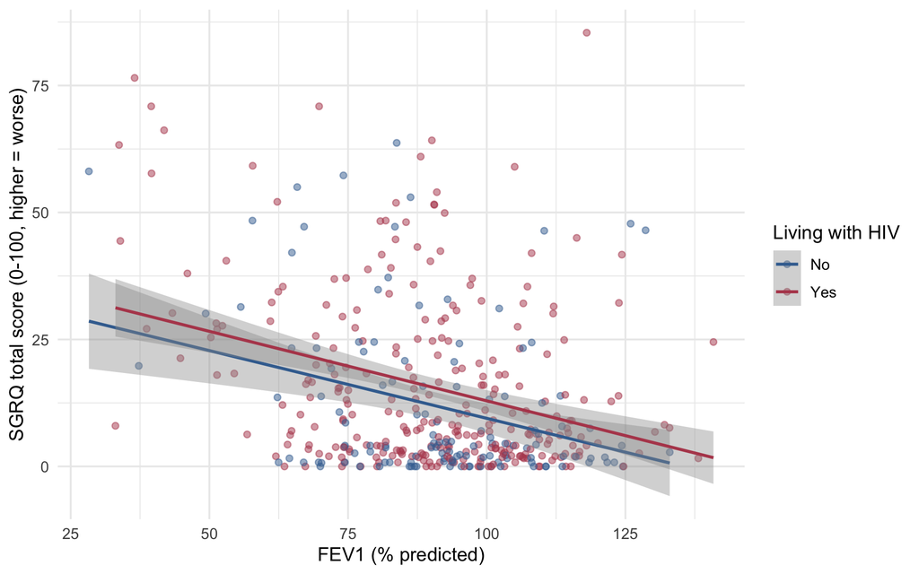

Figure 1. SGRQ total score against FEV1 (% predicted), by HIV status.

Respiratory quality of life worsens as FEV1 falls in both groups, but the cloud is strongly asymmetric — a dense floor of participants reporting no symptoms at every level of lung function, and a scatter of high scores concentrated at low FEV1 — which is the pattern that will show up later as non-constant residual variance.

## Univariable models

| **Characteristic** | **N** | **Beta** | **95% CI** | **p-value** |
| --- | --- | --- | --- | --- |
| Living with HIV | 410 |  |  |  |
| No |  | — | — |  |
| Yes |  | 3.9 | 0.40, 7.4 | 0.029 |
| Age (years) | 410 | -0.02 | -0.18, 0.14 | 0.8 |
| Sex | 410 |  |  |  |
| Male |  | — | — |  |
| Female |  | 5.4 | 2.1, 8.7 | 0.001 |
| Current smoker | 410 |  |  |  |
| No |  | — | — |  |
| Yes |  | 6.3 | 3.1, 9.5 | <0.001 |
| Smoking (pack-years) | 410 | 0.18 | 0.09, 0.28 | <0.001 |
| Systolic BP (mmHg) | 410 | 0.08 | -0.02, 0.19 | 0.11 |
| Diastolic BP (mmHg) | 410 | -0.01 | -0.16, 0.15 | >0.9 |
| Haemoglobin (g/dL) | 410 | -1.1 | -2.1, -0.15 | 0.024 |
| FEV1 (% predicted) | 410 | -0.27 | -0.35, -0.20 | <0.001 |
| FVC (% predicted) | 410 | -0.19 | -0.28, -0.09 | <0.001 |
| DLCO (% predicted) | 410 | -0.15 | -0.25, -0.06 | 0.001 |

Abbreviation: CI = Confidence Interval

Crudely, participants living with HIV score 3.90 points (95% CI 0.40 to 7.40) higher on the SGRQ, i.e. worse respiratory quality of life (p = 0.029), a difference just at the four-point minimal important threshold. Airflow is the strongest crude correlate: each additional percentage point of predicted FEV1 is associated with -0.27 points (95% CI -0.35 to -0.20) (p <0.001), so a 20-point deficit in FEV1 corresponds to about 5.5 SGRQ points. FVC (-0.19 points (95% CI -0.28 to -0.09), p <0.001) and DLCO (-0.15 points (95% CI -0.25 to -0.06), p = 0.001) show weaker gradients in the same direction. Current smokers score 6.30 points (95% CI 3.09 to 9.52) worse (p <0.001), each pack-year 0.18 points (95% CI 0.09 to 0.28) (p <0.001), women 5.39 points (95% CI 2.09 to 8.70) worse than men (p = 0.001), and each additional g/dL of haemoglobin is associated with -1.13 points (95% CI -2.12 to -0.15) (p = 0.024). Age (-0.02 points (95% CI -0.18 to 0.14), p = 0.801) and both blood pressures show no crude association.

## Why adjustment is needed

**Current smoking** is the obvious confounder of the HIV association. 45% of participants with HIV are current smokers against 42% of the HIV-negative group, and current smoking is itself associated with 6.30 points (95% CI 3.09 to 9.52) on the SGRQ, partly through cough and sputum questions in the symptoms domain that ask directly about smoking-related complaints. **Airflow obstruction** is the second: FEV1 is the strongest crude predictor of the SGRQ here, and it differs between the two groups, so any crude HIV difference is partly a lung-function difference. **Sex** is a third and works in the opposite direction from the naive expectation: women in this sample have *better* measured lung function (median FEV1 94% versus 91% of predicted) but report *worse* respiratory quality of life, so leaving sex out would make the lung-function coefficients look smaller than they are. Mutual adjustment lets each estimate be read as a comparison between participants alike on the other measured characteristics.

## Multivariable model

| **Characteristic** | **Beta** | **95% CI** | **p-value** |
| --- | --- | --- | --- |
| Living with HIV |  |  |  |
| No | — | — |  |
| Yes | 4.1 | 0.90, 7.4 | 0.012 |
| Age (years) | -0.15 | -0.30, 0.01 | 0.060 |
| Sex |  |  |  |
| Male | — | — |  |
| Female | 5.5 | 1.9, 9.1 | 0.003 |
| Current smoker |  |  |  |
| No | — | — |  |
| Yes | 3.4 | 0.18, 6.7 | 0.039 |
| Smoking (pack-years) | 0.07 | -0.03, 0.18 | 0.2 |
| Systolic BP (mmHg) | 0.22 | 0.09, 0.34 | <0.001 |
| Diastolic BP (mmHg) | -0.17 | -0.35, 0.01 | 0.065 |
| Haemoglobin (g/dL) | -0.60 | -1.7, 0.46 | 0.3 |
| FEV1 (% predicted) | -0.51 | -0.67, -0.35 | <0.001 |
| FVC (% predicted) | 0.32 | 0.14, 0.50 | <0.001 |
| DLCO (% predicted) | -0.01 | -0.12, 0.09 | 0.8 |

Abbreviation: CI = Confidence Interval

**Model fit: multivariable linear model for SGRQ total score**

| Statistic | Value |
| --- | --- |
| Complete-case N | 410 |
| Parameters (excl. intercept) | 11 |
| Observations per parameter | 37.3 |
| R-squared | 0.231 |
| Adjusted R-squared | 0.210 |
| Residual SE (SGRQ points) | 14.9 |

The model explains 23.1% of the variance in the SGRQ total (adjusted R-squared 0.210), with a residual standard deviation of 14.9 points — nearly four times the minimal important difference, so individual scores are not predictable from these characteristics.

Among participants of the same age, sex, smoking history, blood pressure, haemoglobin and lung function, those living with HIV score 4.13 points (95% CI 0.90 to 7.36) worse (p = 0.012). Airflow remains the dominant correlate: each percentage point of predicted FEV1 is associated with -0.51 points (95% CI -0.67 to -0.35) (p <0.001). The FVC coefficient, 0.32 points (95% CI 0.14 to 0.50) (p <0.001), has flipped to the *opposite* sign from its crude estimate; the two together are effectively encoding the FEV1/FVC ratio, so what the model is really saying is that quality of life tracks airflow *obstruction* rather than lung size (see Diagnostics). Among participants alike on everything else, women score 5.45 points (95% CI 1.85 to 9.05) worse than men (p = 0.003), current smokers 3.45 points (95% CI 0.18 to 6.71) worse than non-current smokers (p = 0.039), and each mmHg of systolic pressure 0.22 points (95% CI 0.09 to 0.34) (p <0.001). Age (-0.15 points (95% CI -0.30 to 0.01)), pack-years (0.07 points (95% CI -0.03 to 0.18)), diastolic pressure, haemoglobin and DLCO (-0.01 points (95% CI -0.12 to 0.09)) are not independently associated. These are associations among the participants observed, not effects of intervening.

## Unadjusted versus adjusted

**Table 2. Unadjusted and adjusted estimates.**

| **Characteristic** | **Unadjusted** **N** | **Unadjusted** **Beta** | **Unadjusted** **95% CI** | **Unadjusted** **p-value** | **Adjusted** **Beta** | **Adjusted** **95% CI** | **Adjusted** **p-value** |
| --- | --- | --- | --- | --- | --- | --- | --- |
| Living with HIV | 410 |  |  |  |  |  |  |
| No |  | — | — |  | — | — |  |
| Yes |  | 3.9 | 0.40, 7.4 | 0.029 | 4.1 | 0.90, 7.4 | 0.012 |
| Age (years) | 410 | -0.02 | -0.18, 0.14 | 0.8 | -0.15 | -0.30, 0.01 | 0.060 |
| Sex | 410 |  |  |  |  |  |  |
| Male |  | — | — |  | — | — |  |
| Female |  | 5.4 | 2.1, 8.7 | 0.001 | 5.5 | 1.9, 9.1 | 0.003 |
| Current smoker | 410 |  |  |  |  |  |  |
| No |  | — | — |  | — | — |  |
| Yes |  | 6.3 | 3.1, 9.5 | <0.001 | 3.4 | 0.18, 6.7 | 0.039 |
| Smoking (pack-years) | 410 | 0.18 | 0.09, 0.28 | <0.001 | 0.07 | -0.03, 0.18 | 0.2 |
| Systolic BP (mmHg) | 410 | 0.08 | -0.02, 0.19 | 0.11 | 0.22 | 0.09, 0.34 | <0.001 |
| Diastolic BP (mmHg) | 410 | -0.01 | -0.16, 0.15 | >0.9 | -0.17 | -0.35, 0.01 | 0.065 |
| Haemoglobin (g/dL) | 410 | -1.1 | -2.1, -0.15 | 0.024 | -0.60 | -1.7, 0.46 | 0.3 |
| FEV1 (% predicted) | 410 | -0.27 | -0.35, -0.20 | <0.001 | -0.51 | -0.67, -0.35 | <0.001 |
| FVC (% predicted) | 410 | -0.19 | -0.28, -0.09 | <0.001 | 0.32 | 0.14, 0.50 | <0.001 |
| DLCO (% predicted) | 410 | -0.15 | -0.25, -0.06 | 0.001 | -0.01 | -0.12, 0.09 | 0.8 |

Abbreviation: CI = Confidence Interval

The most dramatic movement is **FVC**, which reverses sign entirely: crude -0.19 points (95% CI -0.28 to -0.09) (p <0.001), adjusted 0.32 points (95% CI 0.14 to 0.50) (p <0.001). This is collinearity with FEV1, not a substantive finding. The two correlate at 0.87 and have VIFs of 4.5 and 4.3; when a negative FEV1 coefficient and a positive FVC coefficient of similar size sit side by side, the pair is behaving as a difference term, which is to say as the FEV1/FVC ratio. **DLCO** is the other big mover, from -0.15 points (95% CI -0.25 to -0.06) crude (p = 0.001) to -0.01 points (95% CI -0.12 to 0.09) adjusted (p = 0.797) — the entire crude gas-transfer association is explained by the spirometry and smoking variables it travels with. **Pack-years** moves the same way, from 0.18 points (95% CI 0.09 to 0.28) to 0.07 points (95% CI -0.03 to 0.18), losing significance, while its companion **current smoking** attenuates only from 6.30 points (95% CI 3.09 to 9.52) to 3.45 points (95% CI 0.18 to 6.71) and keeps it — of the two smoking terms it is present smoking, not lifetime dose, that carries the symptom burden.

Two estimates barely move. **HIV status** goes from 3.90 points (95% CI 0.40 to 7.40) to 4.13 points (95% CI 0.90 to 7.36), if anything slightly *stronger* after adjustment, which means the HIV difference in respiratory quality of life is not explained by the heavier smoking or the lung function of the HIV-positive group. **Sex** likewise holds at 5.39 points (95% CI 2.09 to 8.70) crude and 5.45 points (95% CI 1.85 to 9.05) adjusted. One estimate crosses into significance: **systolic blood pressure**, from 0.08 points (95% CI -0.02 to 0.19) (p = 0.111) to 0.22 points (95% CI 0.09 to 0.34) (p <0.001), which appears only once diastolic pressure is held constant and is best read as a fragile artefact of adjusting one blood-pressure component for the other rather than a discovery about respiratory health.

## Diagnostics

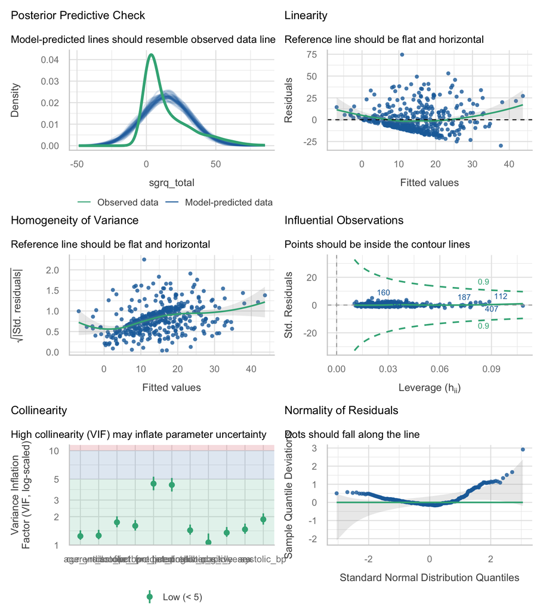

| Term | VIF | VIF_CI_low | VIF_CI_high | SE_factor | Tolerance | Tolerance_CI_low | Tolerance_CI_high |
| --- | --- | --- | --- | --- | --- | --- | --- |
| hiv_positive | 1.066724 | 1.013657 | 1.326007 | 1.032823 | 0.9374494 | 0.7541439 | 0.9865275 |
| age_yrs | 1.244511 | 1.138457 | 1.431799 | 1.115576 | 0.8035285 | 0.6984220 | 0.8783820 |
| sex | 1.467196 | 1.317378 | 1.687737 | 1.211279 | 0.6815721 | 0.5925093 | 0.7590838 |
| current_smoker | 1.261219 | 1.151576 | 1.450173 | 1.123040 | 0.7928836 | 0.6895730 | 0.8683750 |
| pack_years | 1.351871 | 1.223877 | 1.553042 | 1.162700 | 0.7397155 | 0.6438975 | 0.8170758 |
| systolic_bp | 1.870034 | 1.648347 | 2.167524 | 1.367492 | 0.5347495 | 0.4613560 | 0.6066686 |
| diastolic_bp | 1.743036 | 1.543642 | 2.015562 | 1.320241 | 0.5737117 | 0.4961396 | 0.6478186 |
| haemoglobin_g_dl | 1.433876 | 1.290252 | 1.648568 | 1.197446 | 0.6974104 | 0.6065871 | 0.7750422 |
| fev1_pct_predicted | 4.473169 | 3.805013 | 5.300481 | 2.114987 | 0.2235551 | 0.1886621 | 0.2628112 |
| fvc_pct_predicted | 4.338791 | 3.693570 | 5.138571 | 2.082977 | 0.2304789 | 0.1946066 | 0.2707408 |

[output cut: 1 more lines]

**Table 3. HC3 heteroscedasticity-consistent standard errors.**

| Term | Estimate | SE (OLS) | SE (HC3) | 95% CI (HC3) | p (HC3) |
| --- | --- | --- | --- | --- | --- |
| hiv_positiveYes | 4.128 | 1.643 | 1.518 | 1.14 to 7.11 | 0.007 |
| age_yrs | -0.149 | 0.079 | 0.074 | -0.29 to -0.00 | 0.045 |
| sexFemale | 5.453 | 1.831 | 1.952 | 1.62 to 9.29 | 0.005 |
| current_smokerYes | 3.446 | 1.660 | 1.710 | 0.08 to 6.81 | 0.045 |
| pack_years | 0.074 | 0.051 | 0.050 | -0.02 to 0.17 | 0.141 |
| systolic_bp | 0.219 | 0.064 | 0.067 | 0.09 to 0.35 | 0.001 |
| diastolic_bp | -0.170 | 0.092 | 0.088 | -0.34 to 0.00 | 0.056 |
| haemoglobin_g_dl | -0.597 | 0.536 | 0.583 | -1.74 to 0.55 | 0.306 |
| fev1_pct_predicted | -0.510 | 0.079 | 0.082 | -0.67 to -0.35 | 0.000 |
| fvc_pct_predicted | 0.316 | 0.092 | 0.101 | 0.12 to 0.51 | 0.002 |
| dlco_pct_predicted | -0.014 | 0.055 | 0.064 | -0.14 to 0.11 | 0.827 |

The diagnostics are the weakest part of this analysis, and the cause is the shape of the outcome. The SGRQ total is strongly right-skewed (skewness 1.50) with a floor at zero that 38 participants sit on exactly. The posterior-predictive check shows the consequence directly: the model predicts a symmetric spread including negative scores, which the 0-100 scale cannot produce. The residual-versus-fitted panel fans out as fitted values rise — participants predicted to have good respiratory quality of life are tightly clustered near the floor, those predicted to be worse are widely scattered — and `check_heteroscedasticity()` rejects constant variance (p <0.001). `check_normality()` also rejects (p <0.001).

Collinearity is the other flagged check. The two largest VIFs are 4.47 for FEV1 and 4.34 for FVC, against a maximum of 1.87 elsewhere in the model. Both are below the conventional threshold of 5 and both terms are significant, so nothing is unestimable, but the sign flip on FVC is a direct symptom of the two competing and neither coefficient should be quoted alone. No observation exceeds the Cook’s distance contours (maximum 0.047).

# Discussion

In this two-centre US sample, adults living with HIV reported respiratory quality of life about 4.1 SGRQ points worse than HIV-negative adults of the same age, sex, smoking history, blood pressure, haemoglobin and lung function — a difference at the accepted minimal important threshold of four points, and one that is not explained by the heavier smoking or poorer lung function of the HIV-positive group. Airflow is the dominant physiological correlate: the FEV1 and FVC coefficients together amount to saying that obstruction, rather than lung size, is what patients feel. Diffusing capacity, which is the strongest lung-function correlate of *walking distance* in this same dataset, has no independent association with *symptoms* at all — a useful reminder that measured impairment and perceived health are different outcomes. Practically, respiratory symptoms in people with HIV should not be dismissed as smoking alone.

**Limitations.** Participants were recruited at **two clinical centres, Pittsburgh and UCSF, and the site variable is not in this deposit**, although the source paper shows site matters; it is therefore both an unmeasured confounder and an ignored clustering variable, so the standard errors here are probably optimistic. Residual variance is non-constant and residuals are non-normal because the SGRQ has a hard floor that 38 participants occupy; HC3 standard errors repair inference but not the model’s inability to respect the scale bounds. The design is cross-sectional and the outcome is self-reported at the same visit as everything else, so common-method bias and reverse causation are both live: a participant feeling unwell may report worse symptoms *and* perform worse on spirometry on the day. Current smoking and the SGRQ symptoms domain overlap by construction, since the questionnaire asks about cough and sputum, so part of the smoking coefficient is measurement rather than effect. FEV1 and FVC compete for the same variance and the FVC sign flip should not be interpreted substantively. Depression, which is common in this population and strongly influences questionnaire-based quality of life, is not measured. Complete-case analysis dropped 17 of 427 rows (4.0%). All estimates are associations, not causal effects.

**Future work.** Refit with study site as a fixed effect and with a mental-health measure in the adjustment set, and consider a two-part or beta-regression model that respects the floor at zero rather than forcing a symmetric error distribution onto a bounded score.

# Feasibility notes

*NOT part of a student report.*

- **USABLE WITH WARNINGS.** The exposure of interest is significant and stable under adjustment, and the substantive story (obstruction and HIV, not gas transfer) is a good one — but the outcome distribution breaks two assumption checks and the fix costs interpretability.
- **FATAL: the three SGRQ subscales must never be predictors.** `sgrq_total` is the questionnaire’s fixed weighted combination of `sgrq_symptoms`, `sgrq_activity` and `sgrq_impacts`; regressing it on the three returns R-squared 0.9996. A student who reaches for “other respiratory measures in the file” will produce a model that explains essentially all of the variance and whose coefficients are the SGRQ scoring algorithm (0.16 for symptoms, 0.32 for activity, 0.51 for impacts — the published SGRQ weights), not epidemiology. The catalogue lists all four SGRQ columns together and does not warn about this.
- **FATAL if any HIV-restricted variable is used.** `cd4_count`, `on_antiretroviral` and `viral_load_detectable` exist only for the 297 participants with HIV. Adding `on_antiretroviral` here takes the complete-case N from 410 to 284 with **0 HIV-negative participants left**, so `hiv_positive` becomes a constant and the model will not fit at all; adding `cd4_count` takes N to 292 with only 20 HIV-negative participants, which is worse because it fails silently. `six_min_walk_m.Rmd` in this folder quantifies the damage in a table.
- **MAJOR: heteroscedasticity (p <0.001) and non-normality (p <0.001),** both driven by the floor at zero (38 participants score exactly 0, 9% of the sample) and the long right tail (skewness 1.50). A square-root transform fixes the variance (p = 0.231) but not the normality (p <0.001). Any honest student report has to record a failed check here.
- **MAJOR: the FVC coefficient reverses sign on adjustment** (-0.19 points (95% CI -0.28 to -0.09) crude to 0.32 points (95% CI 0.14 to 0.50) adjusted, both significant) because FEV1 and FVC are collinear (r 0.87, VIFs 4.47 and 4.34). This is the single most misinterpretable result in the document: a weak student will report “larger lungs are associated with worse quality of life”. It is salvageable as a teaching point about what a pair of opposite-signed collinear terms means, but it needs to be flagged.
- **MINOR: `mmrc_dyspnoea` is both differentially missing and conceptually circular here.** All 111 missing values are in HIV-positive participants; adding it would take N to 302. It also measures breathlessness, which the SGRQ activity domain measures again.
- **MINOR: `pack_years` and `smoking_status` are structurally entangled** (`pack_years == 0` is exactly `smoking_status == "never"` on all 427 rows). The parameterisation chosen here is documented in Methods; the alternative is defensible but must be justified rather than stumbled into.
- **Complete-case N 410 of 427** (4.0% lost), matching the catalogue’s advertised 410/427.
- **Structural: two-site recruitment with no site variable.** Unfixable from the shipped file; belongs in Limitations. Site also plausibly affects a self-reported questionnaire outcome more than a physiological one.